# Apresentação SER-347

## Avaliação da relação entre a expansão da área agrícola em Ibitinga-SP e o aumento da ocorrência de blooms de algas através de imagens Landsat-5 e dados MAPBIOMAs

# Parte 1 -> Avaliação dados do MAPBIOMAS

## Inicialmente, é feita a localização dos arquivos MAPBIOMAS baixados do GEE

## Após isto, carrega-se um arquivo shapefile com os limites da bacia hidrográfica de Ibitinga

```python
#Verifica os arquivos que estão no diretório

files = os.listdir()
n_files = len(files) #Verifica a quantidade de arquivos
n_files
```

```
27
```

# Metodologias

Inicialmente, a partir do recorte da bacia hidrográfica é possível recortar à área do MAPBIOMAS, que anteriormente era para o estado de Sâo Paulo, para apenas a região de ibitinga. Esta extração é realizada e é contado cada valor de pixel. Como a legenda do MAPBIOMAS possui valores entre 0 e 31, podemos contar os valores únicos. A resolução de espacial de 30m permite que se obtenham valores de area ao multiplicar os pixels por 900 (para valores em m²).

# Área de estudo

A área de estudo é o reservatório de Ibitinga localizado na bacia do Tietê/Jacaré, no médio Tietê, na região central do estado de São Paulo. O reservatório encontra-se a jusante do reservatório da Usina Hidrelétrica de Bariri, e a montante do reservatório da Usina Hidrelétrica de Promissão. Em geral, o uso da terra nas margens do reservatório é caracterizado pelo predomínio de pastagens e restritas áreas de capoeira e reflorestamento, ao lado de expressivas áreas de cana-de-açúcar e citricultura presentes desde o trecho médio até as cabeceiras dos seus dois principais afluentes. Vale ressaltar que essa região é considerada uma das áreas de maior expansão da cana-de-açúcar nos últimos 10 anos. Além disso, a água da bacia é utilizada para abastecimento público e industrial, descarga de efluentes domésticos e industriais, irrigação, navegação, além da geração de energia elétrica (CETESB, 2005; GUIMARÃES Jr. et al., 1998; RUDORFF et al., 2010).

Processamento dos dados do Mapbiomas:

1. Recorte dos dados para a área de estudo
2. Análise temporal de cada classe do uso e cobertura da terra
3. Elaboração do gráfico com a série temporal por classe

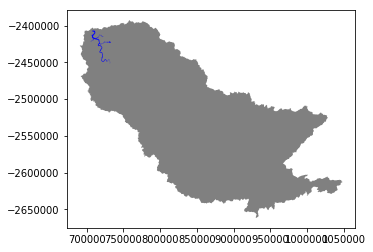

```python
ax = shp.plot(color = 'gray')
shp2.plot(axes = ax, color = 'blue')
```

# Dados

```python
#Verificar a área de cada classe na bacia de Ibitinga

for i in range(0,n_files):

    img1 = rio.open(files[i])
    nome = img1.name.split('_')[1][0:4]

    img_crop, img_affine = mask(img1,[extent_geojson], crop = True)

    unique, counts = np.unique(img_crop, return_counts = True)

    if 'res' in locals():  #Se res existe adiciono uma coluna

        res['Ano' + '_' + str(nome)] = counts

    else:

        res = pd.DataFrame(counts,unique, columns = ['Ano'+ '_' + str(nome)])

    print(i)
```

```
0
1
2
3
4
5
6
7
8
9
10
11
12
13
14
15
16
17
18
19
20
21
22
23
24
25
26
```

```python
legenda_mapbiomas
```

```
('Nada',
 'Floresta Natural',
 'Formação Savânica',
 'Floresta Plantada',
 'Formação Campestre',
 'Pastagem',
 'Cultura Anual e Perene',
 'Cultura Semi-Perene',
 'Mosaico de Agircultura e Pastagem',
 'Area Urbana',
 'Outra Area n vegetada',
 'Nao Observado',
 'Mineracao',
 'Lagos')
```

## Após a importação da legenda, podemos adicioná-la ao data frame criado para armazenar os dados de área.

A matriz (data.frame) é transposta e é adicionado aos títulos das colunas as classes do MAPBIOMAS

```python
results_trasnpose
```

|  | Nada | Floresta Natural | Formação Savânica | Floresta Plantada | Formação Campestre | Pastagem | Cultura Anual e Perene | Cultura Semi-Perene | Mosaico de Agircultura e Pastagem | Area Urbana | Outra Area n vegetada | Nao Observado | Mineracao | Lagos | Data |
| --- | --- | --- | --- | --- | --- | --- | --- | --- | --- | --- | --- | --- | --- | --- | --- |
| Ano_1985 | 62742792 | 10224663 | 51537 | 316575 | 161356 | 17718317 | 18553 | 3908883 | 16476980 | 3032713 | 96673 | 1892 | 5180 | 869566 | 1985 |
| Ano_1986 | 62742792 | 10240154 | 45894 | 399102 | 166610 | 17780947 | 32968 | 3937213 | 16251542 | 3037916 | 121167 | 1835 | 3870 | 863670 | 1986 |
| Ano_1987 | 62742792 | 9854307 | 42580 | 640536 | 136176 | 17771218 | 23515 | 4414334 | 15978326 | 3030857 | 74034 | 1598 | 3968 | 911439 | 1987 |
| Ano_1988 | 62742792 | 9795349 | 37194 | 627607 | 138537 | 17734006 | 15150 | 4703471 | 15710455 | 3110221 | 92575 | 1472 | 4515 | 912336 | 1988 |
| Ano_1989 | 62742792 | 9857223 | 38256 | 673821 | 134978 | 17375472 | 27652 | 4907550 | 15762020 | 3103553 | 96831 | 1500 | 4609 | 899423 | 1989 |
| Ano_1990 | 62742792 | 10039323 | 36845 | 611578 | 130389 | 17081420 | 18397 | 5077234 | 15730953 | 3135273 | 90934 | 1413 | 5582 | 923547 | 1990 |
| Ano_1991 | 62742792 | 10013311 | 29804 | 737327 | 133681 | 16633232 | 17833 | 4701807 | 16492483 | 3076494 | 91362 | 1488 | 4518 | 949548 | 1991 |
| Ano_1992 | 62742792 | 9889942 | 30676 | 781842 | 139222 | 16363108 | 32809 | 5515481 | 16023397 | 3106457 | 101478 | 1493 | 4120 | 892863 | 1992 |
| Ano_1993 | 62742792 | 10015726 | 20654 | 734795 | 128577 | 15915564 | 50216 | 5844002 | 16011113 | 3182001 | 79176 | 1692 | 3854 | 895518 | 1993 |
| Ano_1994 | 62742792 | 9997703 | 34853 | 896335 | 178360 | 15533342 | 33951 | 6201368 | 15874819 | 3120672 | 105755 | 1730 | 4984 | 899016 | 1994 |
| Ano_1995 | 62742792 | 9987841 | 41688 | 806179 | 132451 | 14488163 | 80471 | 6670192 | 16483549 | 3155943 | 100579 | 1658 | 6657 | 927517 | 1995 |
| Ano_1996 | 62742792 | 10042927 | 34607 | 914235 | 133378 | 14943885 | 31309 | 6414872 | 16108930 | 3218413 | 97215 | 1812 | 5531 | 935774 | 1996 |
| Ano_1997 | 62742792 | 9938201 | 39578 | 905913 | 159078 | 14145446 | 62910 | 6708163 | 16679292 | 3191875 | 103419 | 1747 | 7056 | 940210 | 1997 |
| Ano_1998 | 62742792 | 9733805 | 56708 | 945486 | 135272 | 13860107 | 63242 | 6726589 | 17017237 | 3299877 | 109460 | 1838 | 5505 | 927762 | 1998 |
| Ano_2000 | 62742792 | 9721477 | 45438 | 966769 | 148197 | 13669136 | 38091 | 6839151 | 17099647 | 3315694 | 100787 | 1758 | 10634 | 926109 | 1999 |
| Ano_2001 | 62742792 | 9693928 | 54988 | 1029601 | 177399 | 13528371 | 40639 | 6947722 | 16980957 | 3410292 | 117284 | 1748 | 12548 | 887411 | 2000 |
| Ano_2002 | 62742792 | 9626062 | 88881 | 1105028 | 159876 | 12941725 | 87633 | 7628836 | 16689293 | 3551313 | 92927 | 1724 | 10848 | 898742 | 2001 |
| Ano_2003 | 62742792 | 9740369 | 80910 | 1061011 | 178233 | 13362437 | 54531 | 7135948 | 16771503 | 3495357 | 101010 | 1709 | 11528 | 888342 | 2002 |
| Ano_2004 | 62742792 | 9578471 | 105221 | 1091371 | 167232 | 12569214 | 92747 | 7991789 | 16694191 | 3514998 | 157332 | 1894 | 13204 | 905224 | 2003 |
| Ano_2005 | 62742792 | 9661781 | 82213 | 1094199 | 164417 | 12202941 | 126186 | 8366939 | 16604511 | 3545003 | 120814 | 1865 | 10824 | 901195 | 2004 |
| Ano_2006 | 62742792 | 9755611 | 102664 | 1161050 | 181728 | 10978747 | 149848 | 8797380 | 17019340 | 3655441 | 143154 | 1664 | 12826 | 923435 | 2005 |
| Ano_2007 | 62742792 | 9733135 | 96476 | 1113675 | 165440 | 11719602 | 119001 | 8597783 | 16675992 | 3616203 | 103628 | 1879 | 11439 | 928635 | 2006 |
| Ano_2008 | 62742792 | 9768879 | 86159 | 1216671 | 171992 | 10203382 | 168180 | 9179228 | 17371429 | 3623570 | 152897 | 1702 | 10497 | 928302 | 2007 |
| Ano_2009 | 62742792 | 9916304 | 68100 | 1291622 | 154663 | 9525736 | 161026 | 9912043 | 17077953 | 3694325 | 145000 | 1826 | 11970 | 922320 | 2008 |
| Ano_2010 | 62742792 | 10022192 | 45614 | 1366076 | 173091 | 8972561 | 166767 | 10207534 | 17057826 | 3803822 | 126858 | 1817 | 10780 | 927950 | 2009 |
| Ano_2011 | 62742792 | 10047688 | 60770 | 1433065 | 193305 | 8307114 | 245605 | 10198587 | 17513799 | 3830180 | 105833 | 1879 | 12402 | 932661 | 2010 |
| Ano_2012 | 62742792 | 10099286 | 42573 | 1504856 | 206909 | 7904854 | 267928 | 10179528 | 17790363 | 3797113 | 134661 | 2004 | 14417 | 938396 | 2011 |

# Resultados MAPBIOMAS - Mudanças no uso do solo

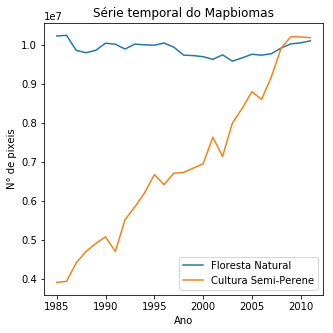

```python
#Plota a série temporal para algumas classes de interesse para os anos analisados
plt.figure(figsize = (5,5))
plt.plot(results_trasnpose["Data"], results_trasnpose["Floresta Natural"], label = 'Floresta Natural')
plt.plot(results_trasnpose["Data"], results_trasnpose["Cultura Semi-Perene"], label = 'Cultura Semi-Perene')
plt.xlabel('Ano')
plt.ylabel('N° de pixeis')
plt.title('Série temporal do Mapbiomas')
plt.legend()
```

A partir da primeira parte, pode-se avaliar que houve um aumento da área de cultura semi-perene, relacionada principalmente à expensão da cultura de cana de açucar (classe semi-perene) na região.

# Parte 2 - Estimativa da ocorrência de blooms

## Dados

Para a estimativa de clorofila foram utilizadas todas as imagens do sensor TM do Landsat 5, disponíveis para a área de estudo com o mínimo de cobertura de nuvens, evitando-se principalmente, a presença de nuvens no reservatório.

Processamento estimativa de clorofila:

1. Download de imagens Landsat-5 TM
2. Recorte com o shape da área de estudo
3. Aplicação do modelo para estimativa de clorofila por ano
4. Análise temporal da clorofila estimada para cada ano

A estimativa da clorofila foi realizada através da razão NIR/RED, calculando o número de pixels que possuiam concentração acima de 100 ug/L, baseando-se nos limiares propostos por Novo et al. (2013). Para isso, foi utilizada uma amostra de mil pontos distribuídos no reservatório.

1. NIR/RED < 0.97 = Chl-a < 100 ug/L
2. NIR/RED > 0.97 = Chl-a > 100 ug/L

## A partir da utilização da razão NIR/RED é possível separar as áreas com bloom e sem bloom

```python
Clorofila_blom = pd.read_csv('Clorofila_blom.csv', index_col=7, parse_dates=True)
```

# É possível fazer também a separação por ano e por mês

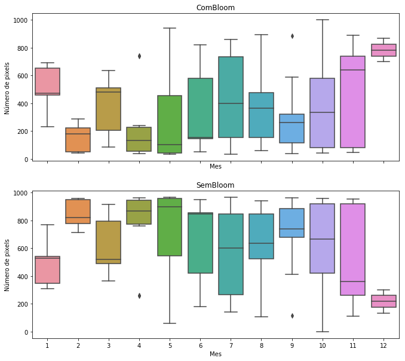

```python
## Utiliza a biblioteca seaborn para fazer os gráficos
fig, axes = plt.subplots(2, 1, figsize=(11, 10), sharex=True)
for name, ax in zip(['ComBloom', 'SemBloom'], axes):
    sns.boxplot(data=Clorofila_blom, x='Mes', y=name, ax=ax)
    ax.set_ylabel('Número de pixels')
    ax.set_title(name)
```

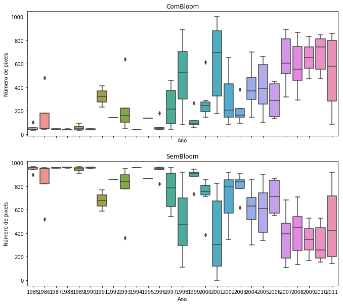

```python
fig, axes = plt.subplots(2, 1, figsize=(11, 10), sharex=True)
for name, ax in zip(['ComBloom', 'SemBloom'], axes):
    sns.boxplot(data=Clorofila_blom, x='Ano', y=name, ax=ax)
    ax.set_ylabel('Número de pixels')
    ax.set_title(name)
```

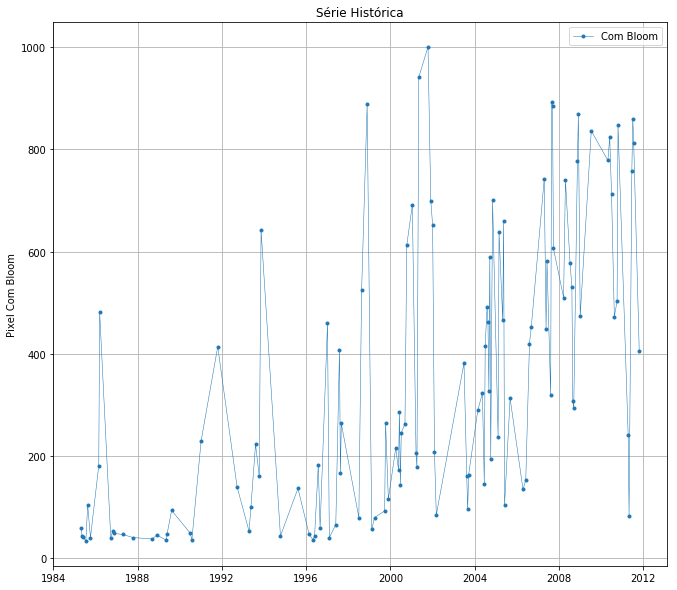

```python
#Plota a série histórica, filtra pros anos
fig, ax = plt.subplots(1, 1, figsize=(11, 10), sharex=True)
ax.plot(Clorofila_blom.loc[start:end, 'ComBloom'], #Pega só a coluna com bloom para o intervalo de datas
marker='.', linestyle='-', linewidth=0.5, label='Com Bloom')
ax.set_ylabel('Pixel Com Bloom')
ax.legend();
ax.set_title("Série Histórica");
plt.autoscale(True)
plt.grid(True)
```

# Comparação dos resultados do MAPBIOMAS com os resultados obtidos para a estimativa de clorofila

```python
##Regressão entre a classe do Mapbiomas e a estimativa de clorofila


from scipy import stats  # Biblioteca para estatística

plt.subplots(1, 1, figsize=(11, 10), sharex=True)

x=results_trasnpose['Cultura Anual e Perene'].as_matrix().astype(float)
y=fil365d['ComBloom'].as_matrix().astype(float)

#Estimativa dos parâmetros da regressão

slope, intercept, r_value, p_value, std_err = stats.linregress(x,y)

#Aplico a regressão para a estimativa dey (clorofila)

predict_y = intercept + slope * x
```

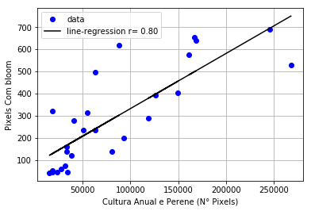

```python
#Plota o gráfico da regressão
plt.plot(x,y,'bo')
plt.plot(x, predict_y, 'k-')
plt.legend(('data', 'line-regression r= 0.80', 'best'))
plt.xlabel("Cultura Anual e Perene (N° Pixels)")
plt.ylabel("Pixels Com bloom")
plt.autoscale(True)
plt.grid(True)
```